# CA1-04-P2426053-Konda Sai Srikar Reddy

Name: Konda Sai Srikar Reddy Title: PDS CA1

DATASET 1: https://data.gov.sg/datasets/d_cb55223f678fb7702181fc95c587e03f/view

DATASET 2: https://data.gov.sg/datasets/d_473f502212568e7cd7c55e699a998f1d/view

DATASET 3: https://data.gov.sg/datasets/d_26bcaadd552d0b77bb13ea9c671bac6b/view

DATASET 4: https://data.gov.sg/datasets/d_1a2ea5e9309802413f650aba1b103166/view

DATASET 5: https://data.gov.sg/datasets/d_668967b5fce80dc42255a3ac1671f97c/view

DATASET 6: https://data.gov.sg/datasets?page=1&query=type+of+dwelling&resultId=d_2917c3a947cd8d8af80dbec6b587281c

Topic statement: What are the various factors affecting the type of dwelling and how they affect the dwelling type over the years

Questions:

*QUESTION 1: HOW HAS DISTRIBUTION OF RESIDENTS ACROSS DIFFERENT HDB FLATS CHANGED OVER THE YEARS*

*QUESTION 2: What is the overall gender distribution across different HDB flat types?*

*QUESTION 3: How is the distribution of average age across different flat types over all years?*

*QUESTION 4:How did the average number of income earners varied across different HDB flat types over the years?*

*QUESTION 5:Do Executive flats have higher percentages of 6-or-more-person households compared to other flat types?*

*QUESTION 6:Which planning area had the most landed property households*

```python
import numpy as np
import matplotlib.pyplot as plt
```

```python
#import data from HDBResidentPopulationAged15YearsandAbovebyFlatType csv file
data1 = np.genfromtxt("HDBResidentPopulationAged15YearsandAbovebyFlatType.csv",
                     delimiter = ',',#splits the columns using commas
                      names = True,# skips the first row of headers
                      dtype=[('shs_year','int'),('flat_type','U10'),('number','int')]) #specifies the data type (U10 means string up to 10 charecters)
year = data1['shs_year']#storing the years
flat = data1['flat_type']#storing the type of flats
residents = data1['number']#storing the number of residents
```

```python
years = np.unique(year)#it only stores all the unique years for example it will only store 1 2008 and not multiple
min_year = np.min(year)#stores the starting year of the data
max_year = np.max(year)#stores the last year of the data
arg_max = np.argmax(residents)#stores the index of the highest number of residents
max_residents = np.max(residents)#stores the highest number of residents
arg_min = np.argmin(residents)#stores the index of the lowest number of residents
min_residents = np.min(residents)#stores the lowest number of residents
print("**Population of residents by flat-type**")#This dataset is about the number of residents leaving in each flat-type
print(f"There are altogether {len(year)} rows in dataset:'HDBResidentPopulationAged15YearsandAbovebyFlatType'")#Showing the number of rows in dataset
print(f"There are {len(years)} years of unique data from {min_year} to {max_year}")#shows the span of the dataset
print(f"The flat with most number of residents is {flat[arg_max]} with {max_residents} residents in {year[arg_max]}")#shows which flat is the most popular
print(f"The flat with least number of residents is {flat[arg_min]} with {min_residents} residents in {year[arg_min]}")#shows which flat is the least popular
```

```
**Population of residents by flat-type**
There are altogether 18 rows in dataset:'HDBResidentPopulationAged15YearsandAbovebyFlatType'
There are 3 years of unique data from 2008 to 2018
The flat with most number of residents is 4-room with 1084000 residents in 2018
The flat with least number of residents is 1-room with 33000 residents in 2008
```

*QUESTION 1: HOW HAS DISTRIBUTION OF RESIDENTS ACROSS DIFFERENT HDB FLATS CHANGED OVER THE YEARS*

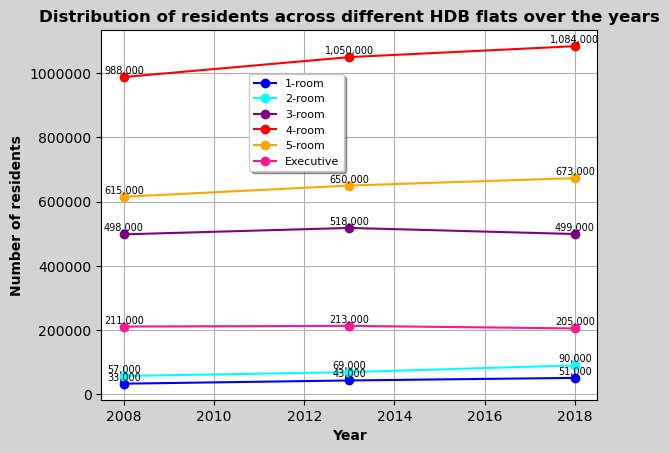

[output not shown]

```python
fig,ax = plt.subplots()#returns a tuple containing a figure and axes
fig.set_facecolor("lightgray")#sets the background color of the figure to lightgray
plt.xlabel("Year", fontweight = "bold")#labels the x axis as 'year'
plt.ylabel("Number of residents",fontweight="bold")#labels the y axis as 'Number of residents'
plt.title("Distribution of residents across different HDB flats over the years",fontweight="bold")#sets the title of the figure
plt.ylim(min(residents)-50000,max(residents)+50000)#sets appropriate y-coordinate values
plt.ticklabel_format(style='plain', axis='y')# formats the values in y coordiate into numbers rather than exponential numbers
OneRoom_residents = residents[flat == '1-room']# stores the number of residents living in 1-room flats for each year in a array
OneRoom_year = year[flat=='1-room']#stores the years corresponding to 1-room flats
TwoRoom_residents = residents[flat=='2-room']# stores the number of residents living in 2-room flats for each year in a array
TwoRoom_year = year[flat=="2-room"]#stores the years corresponding to 2-room flats
ThreeRoom_residents = residents[flat=='3-room']# stores the number of residents living in 3-room flats for each year in a array
ThreeRoom_year = year[flat=="3-room"]#stores the years corresponding to 3-room flats
FourRoom_residents = residents[flat=='4-room']# stores the number of residents living in 4-room flats for each yearin a array
FourRoom_year = year[flat=="4-room"]#stores the years corresponding to 4-room flats
FiveRoom_residents = residents[flat=='5-room']# stores the number of residents living in 5-room flats for each year in a array
FiveRoom_year = year[flat=="5-room"]#stores the years corresponding to 5-room flats
Executive_residents = residents[flat=='Executive']# stores the number of residents living in executive flats for each yearin a array
Executive_year = year[flat=="Executive"]#stores the years corresponding to executive flats
plt.plot(OneRoom_year,OneRoom_residents,color="blue", marker="o",label="1-room")#plots a blue line showing how 1 room flat residents changed over time
plt.plot(TwoRoom_year,TwoRoom_residents,color="cyan",marker="o",label="2-room")#plots a cyan line showing how 2 room flat residents changed over time
plt.plot(ThreeRoom_year,ThreeRoom_residents,color="purple",marker="o",label="3-room")#plots a purple line showing how 3 room flat residents changed over time
plt.plot(FourRoom_year,FourRoom_residents,color="red",marker="o",label="4-room")#plots a red line showing how 4 room flat residents changed over time
plt.plot(FiveRoom_year,FiveRoom_residents,color="orange",marker="o",label="5-room")#plots a orange line showing how 5 room flat residents changed over time
plt.plot(Executive_year,Executive_residents,color="deeppink",marker="o",label="Executive")#plots a pink line showing how Executive flat residents changed over time
legend = plt.legend(loc="best",bbox_to_anchor=(0.5, 0.75),shadow = True,fontsize = 8)#inputs a legend with the best location and with a shadow
plt.grid(True)#puts in a grid
for x, y in zip(OneRoom_year, OneRoom_residents):
    plt.text(x, y + 10000, f"{y:,}", fontsize=7, ha='center')#data labels for 1 room
for x, y in zip(TwoRoom_year, TwoRoom_residents):
    plt.text(x, y + 10000, f"{y:,}", fontsize=7, ha='center')#data labels for two room
for x, y in zip(ThreeRoom_year, ThreeRoom_residents):
    plt.text(x, y + 10000, f"{y:,}", fontsize=7, ha='center')#data labels for three roomm
for x, y in zip(FourRoom_year, FourRoom_residents):
    plt.text(x, y+10000, f"{y:,}", fontsize=7, ha='center')#data labels for four room
for x, y in zip(FiveRoom_year, FiveRoom_residents):
    plt.text(x, y+10000, f"{y:,}", fontsize=7, ha='center')#data labels for five room
for x, y in zip(Executive_year, Executive_residents):
    plt.text(x, y + 10000, f"{y:,}", fontsize=7, ha='center')#data labels for executive
plt.show()#shows the plotting
print("The graph shows how occupancy of different flat types changed over the years. Starting off with 4 room flats, which has the highest number of residents throughout all the years, 4 room flats occupancy just kept on increasing consistently from 2008 with 988000 residents in 2008 to 1084000 residents in 2018 indicating that 4 room flat is the most popular flat type out of all the flats.Moving on to 5 room flats, they also showed a steady increase in occupancy over the years. Starting off with 615000 residents in 2008, it went up to 650000 in 2013 and finally reached 673000 in 2018. This shows that 5 room flats are also a popular choice among residents, just slightly behind 4 room flats.As for 3 room flats, the number of residents remained relatively stable. It started with 498000 residents in 2008, saw a slight rise to 518000 in 2013, but then dropped back to 499000 in 2018. This indicates that the demand for 3 room flats has been inconsistent showing a sudden rise and sudden drop.Executive flats showed a different trend. The number of residents went from 211000 in 2008 to 213000 in 2013, but then slightly decreased to 205000 in 2018. This could suggest that executive flats are slowly becoming less preferred compared to other flat types.Looking at 2 room flats, the trend was clearly increasing. In 2008, there were 57000 residents, which increased to 69000 in 2013 and then rose sharply to 90000 in 2018. This sharp rise may reflect the growing need for smaller flats, possibly for elderly or smaller households.Finally, 1 room flats had the lowest number of residents throughout all the years. Even so, there was a gradual increase from 33000 in 2008 to 43000 in 2013 and then to 51000 in 2018. Despite having the smallest numbers, the steady rise shows that there is still a growing demand for these types of flats.In summary, the graph shows that 4 room and 5 room flats continue to be the most popular among residents, while smaller flat types like 1 room and 2 room flats are also gaining more attention over the year, and three room and executive flats getting less popular.")
```